# Exporting trees with data

Guangchuang Yu School of Basic Medical Sciences, Southern Medical University

2018-11-29

# Introduction

The [treeio](https://bioconductor.org/packages/treeio/) package supports parsing various phylogenetic tree file formats including software outputs that contain evolutionary evidences. Some of the formats are just log file (*e.g.* [PAML](http://abacus.gene.ucl.ac.uk/software/paml.html) and r8s outputs), while some of the others are non-standard formats (*e.g.* [BEAST](http://beast2.org/) and [MrBayes](http://nbisweden.github.io/MrBayes/) outputs that introduce square bracket, which was reserved to store comment in standard Nexus format, to store inferences). With [treeio](https://bioconductor.org/packages/treeio/), we are now able to parse these files to extract phylogenetic tree and map associated data on the tree structure. Exporting tree structure is easy, users can use `as.phyo` method defined [treeio](https://bioconductor.org/packages/treeio/) to convert `treedata` object to `phylo` object then using `write.tree` or `write.nexus` implemented in [ape](https://cran.r-project.org/web/packages/ape/index.html) package (Paradis, Claude, and Strimmer 2004) to export the tree structure as Newick text or Nexus file. This is quite useful for converting non-standard formats to standard format and for extracting tree from software outputs, such as log file.

However, exporting tree with associated data is still challenging. These associated data can be parsed from analysis programs or obtained from external sources (*e.g.* phenotypic data, experimental data and clinical data). The major obstacle here is that there is no standard format that designed for storing tree with data. [NeXML](http://www.nexml.org/) (Vos et al. 2012) maybe the most flexible format, however it is currently not widely supported. Most of the analysis programs in this field rely extensively on Newick string and Nexus format. In my opinion, although BEAST Nexus format[^1] may not be the best solution, it is currently a good approach for storing heterogeneous associated data. The beauty of the format is that all the annotate elements are stored within square bracket, which is reserved for comments. So that the file can be parsed as standard Nexus by ignoring annotate elements and existing programs should be able to read them.

# Exporting tree data to BEAST Nexus format

## Exporting/converting software output

The [treeio](https://bioconductor.org/packages/treeio/) package provides `write.beast` to export `treedata` object as BEAST Nexus file (Bouckaert et al. 2014). With [treeio](https://bioconductor.org/packages/treeio/), it is easy to convert software output to BEAST format if the output can be parsed by [treeio](https://bioconductor.org/packages/treeio/). For example, we can convert NHX file to BEAST file and use NHX tags to color the tree using FigTree[^2] or convert CODEML output and use *d<sub>N</sub>/d<sub>S</sub>*, *d<sub>N</sub>* or *d<sub>S</sub>* to color the tree in FigTree.

```r
nhxfile <- system.file("extdata/NHX", "phyldog.nhx", package="treeio")
nhx <- read.nhx(nhxfile)
# write.beast(nhx, file = "phyldog.tree")
write.beast(nhx)
```

```
#NEXUS
[R-package treeio, Thu Nov 29 23:16:29 2018]

BEGIN TAXA;
    DIMENSIONS NTAX = 16;
    TAXLABELS
        Prayidae_D27SS7@2825365
        Kephyes_ovata@2606431
        Chuniphyes_multidentata@1277217
        Apolemia_sp_@1353964
        Bargmannia_amoena@263997
        Bargmannia_elongata@946788
        Physonect_sp_@2066767
        Stephalia_dilata@2960089
        Frillagalma_vityazi@1155031
        Resomia_ornicephala@3111757
        Lychnagalma_utricularia@2253871
        Nanomia_bijuga@717864
        Cordagalma_sp_@1525873
        Rhizophysa_filiformis@3073669
        Hydra_magnipapillata@52244
        Ectopleura_larynx@3556167
    ;
END;
BEGIN TREES;
    TRANSLATE
        1   Prayidae_D27SS7@2825365,
        2   Kephyes_ovata@2606431,
        3   Chuniphyes_multidentata@1277217,
        4   Apolemia_sp_@1353964,
        5   Bargmannia_amoena@263997,
        6   Bargmannia_elongata@946788,
        7   Physonect_sp_@2066767,
        8   Stephalia_dilata@2960089,
        9   Frillagalma_vityazi@1155031,
        10  Resomia_ornicephala@3111757,
        11  Lychnagalma_utricularia@2253871,
        12  Nanomia_bijuga@717864,
        13  Cordagalma_sp_@1525873,
        14  Rhizophysa_filiformis@3073669,
        15  Hydra_magnipapillata@52244,
        16  Ectopleura_larynx@3556167
    ;
    TREE * UNTITLED = [&R] (((1[&Ev=S,S=58,ND=0]:0.0682841,(2[&Ev=S,S=69,ND=1]:0.0193941,3[&Ev=S,S=70,ND=2]:0.0121378)[&Ev=S,S=60,ND=3]:0.0217782)[&Ev=S,S=36,ND=4]:0.0607598,((4[&Ev=S,S=31,ND=9]:0.11832,(((5[&Ev=S,S=37,ND=10]:0.0144549,6[&Ev=S,S=38,ND=11]:0.0149723)[&Ev=S,S=33,ND=12]:0.0925388,7[&Ev…
END;
```

[figure not shown]

```r
mlcfile <- system.file("extdata/PAML_Codeml", "mlc", package="treeio")
ml <- read.codeml_mlc(mlcfile)
# write.beast(ml, file = "codeml.tree")
write.beast(ml)
```

```
#NEXUS
[R-package treeio, Thu Nov 29 23:16:29 2018]

BEGIN TAXA;
    DIMENSIONS NTAX = 15;
    TAXLABELS
        A
        B
        C
        D
        E
        F
        G
        H
        I
        J
        K
        L
        M
        N
        O
    ;
END;
BEGIN TREES;
    TRANSLATE
        1   A,
        2   B,
        3   C,
        4   D,
        5   E,
        6   F,
        7   G,
        8   H,
        9   I,
        10  J,
        11  K,
        12  L,
        13  M,
        14  N,
        15  O
    ;
    TREE * UNTITLED = [&U] (11[&t=0.082,N=1514.9,S=633.1,dN_vs_dS=0.0224,dN=0.002,dS=0.0878,N_x_dN=3,S_x_dS=55.6]:0.081785,14[&t=0.062,N=1514.9,S=633.1,dN_vs_dS=0.0095,dN=7e-04,dS=0.0689,N_x_dN=1,S_x_dS=43.6]:0.062341,(4[&t=0.082,N=1514.9,S=633.1,dN_vs_dS=0.0385,dN=0.0033,dS=0.0849,N_x_dN=5,S_x_dS=5…
END;
```

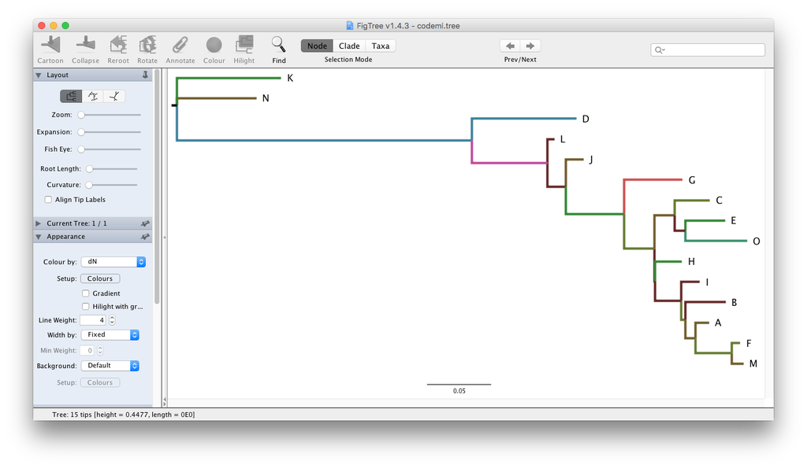

## Combining tree with external data

Using the utilities provided by [treeio](https://bioconductor.org/packages/treeio/), it is easy to link external data onto the corresponding phylogeny. The `write.beast` function enable users to combine the tree with external data to a single tree file.

```r
phylo <- as.phylo(nhx)
## print the newick text
write.tree(phylo)
```

```
[1] "(((Prayidae_D27SS7@2825365:0.0682841,(Kephyes_ovata@2606431:0.0193941,Chuniphyes_multidentata@1277217:0.0121378):0.0217782):0.0607598,((Apolemia_sp_@1353964:0.11832,(((Bargmannia_amoena@263997:0.0144549,Bargmannia_elongata@946788:0.0149723):0.0925388,Physonect_sp_@2066767:0.077429):0.0274637,(S…
```

```r
N <- Nnode2(phylo)
fake_data <- data_frame(node = 1:N, fake_trait = rnorm(N), another_trait = runif(N))
fake_tree <- treedata(phylo = phylo, data = fake_data)
write.beast(fake_tree)
```

```
#NEXUS
[R-package treeio, Thu Nov 29 23:16:29 2018]

BEGIN TAXA;
    DIMENSIONS NTAX = 16;
    TAXLABELS
        Prayidae_D27SS7@2825365
        Kephyes_ovata@2606431
        Chuniphyes_multidentata@1277217
        Apolemia_sp_@1353964
        Bargmannia_amoena@263997
        Bargmannia_elongata@946788
        Physonect_sp_@2066767
        Stephalia_dilata@2960089
        Frillagalma_vityazi@1155031
        Resomia_ornicephala@3111757
        Lychnagalma_utricularia@2253871
        Nanomia_bijuga@717864
        Cordagalma_sp_@1525873
        Rhizophysa_filiformis@3073669
        Hydra_magnipapillata@52244
        Ectopleura_larynx@3556167
    ;
END;
BEGIN TREES;
    TRANSLATE
        1   Prayidae_D27SS7@2825365,
        2   Kephyes_ovata@2606431,
        3   Chuniphyes_multidentata@1277217,
        4   Apolemia_sp_@1353964,
        5   Bargmannia_amoena@263997,
        6   Bargmannia_elongata@946788,
        7   Physonect_sp_@2066767,
        8   Stephalia_dilata@2960089,
        9   Frillagalma_vityazi@1155031,
        10  Resomia_ornicephala@3111757,
        11  Lychnagalma_utricularia@2253871,
        12  Nanomia_bijuga@717864,
        13  Cordagalma_sp_@1525873,
        14  Rhizophysa_filiformis@3073669,
        15  Hydra_magnipapillata@52244,
        16  Ectopleura_larynx@3556167
    ;
    TREE * UNTITLED = [&R] (((1[&fake_trait=-0.828664982501132,another_trait=0.493658386403695]:0.0682841,(2[&fake_trait=0.207292341878713,another_trait=0.173358410829678]:0.0193941,3[&fake_trait=0.18062225206321,another_trait=0.636755054583773]:0.0121378)[&fake_trait=-0.836409125053363,another_trai…
END;
```

## Merging tree data from different sources

Not only Newick tree text can be combined with associated data, but also tree data obtained from software output can be combined with external data, as well as different tree objects can be merged together. For details, please refer to the Importer vignette.

```r
## combine tree object with data
tree_with_data <- full_join(nhx, fake_data, by = "node")
tree_with_data
```

```
## 'treedata' S4 object that stored information of
##  'C:/Users/biocbuild/bbs-3.8-bioc/tmpdir/Rtmp84OrDx/Rinst1cd469b11a3c/treeio/extdata/NHX/phyldog.nhx'.
##
## ...@ phylo:
## Phylogenetic tree with 16 tips and 15 internal nodes.
##
## Tip labels:
##  Prayidae_D27SS7@2825365, Kephyes_ovata@2606431, Chuniphyes_multidentata@1277217, Apolemia_sp_@1353964, Bargmannia_amoena@263997, Bargmannia_elongata@946788, ...
##
## Rooted; includes branch lengths.
##
## with the following features available:
##  'Ev',   'S',    'ND',   'fake_trait',   'another_trait'.
```

```r
## merge two tree object
tree2 <- merge_tree(nhx, fake_tree)
tree2
```

```
## 'treedata' S4 object that stored information of
##  'C:/Users/biocbuild/bbs-3.8-bioc/tmpdir/Rtmp84OrDx/Rinst1cd469b11a3c/treeio/extdata/NHX/phyldog.nhx'.
##
## ...@ phylo:
## Phylogenetic tree with 16 tips and 15 internal nodes.
##
## Tip labels:
##  Prayidae_D27SS7@2825365, Kephyes_ovata@2606431, Chuniphyes_multidentata@1277217, Apolemia_sp_@1353964, Bargmannia_amoena@263997, Bargmannia_elongata@946788, ...
##
## Rooted; includes branch lengths.
##
## with the following features available:
##  'Ev',   'S',    'ND',   'fake_trait',   'another_trait'.
```

```r
identical(tree_with_data, tree2)
```

```
## [1] TRUE
```

After merging data from different sources, the tree with the associated data can be exported into a single file.

```r
write.beast(tree2)
```

```
#NEXUS
[R-package treeio, Thu Nov 29 23:16:29 2018]

BEGIN TAXA;
    DIMENSIONS NTAX = 16;
    TAXLABELS
        Prayidae_D27SS7@2825365
        Kephyes_ovata@2606431
        Chuniphyes_multidentata@1277217
        Apolemia_sp_@1353964
        Bargmannia_amoena@263997
        Bargmannia_elongata@946788
        Physonect_sp_@2066767
        Stephalia_dilata@2960089
        Frillagalma_vityazi@1155031
        Resomia_ornicephala@3111757
        Lychnagalma_utricularia@2253871
        Nanomia_bijuga@717864
        Cordagalma_sp_@1525873
        Rhizophysa_filiformis@3073669
        Hydra_magnipapillata@52244
        Ectopleura_larynx@3556167
    ;
END;
BEGIN TREES;
    TRANSLATE
        1   Prayidae_D27SS7@2825365,
        2   Kephyes_ovata@2606431,
        3   Chuniphyes_multidentata@1277217,
        4   Apolemia_sp_@1353964,
        5   Bargmannia_amoena@263997,
        6   Bargmannia_elongata@946788,
        7   Physonect_sp_@2066767,
        8   Stephalia_dilata@2960089,
        9   Frillagalma_vityazi@1155031,
        10  Resomia_ornicephala@3111757,
        11  Lychnagalma_utricularia@2253871,
        12  Nanomia_bijuga@717864,
        13  Cordagalma_sp_@1525873,
        14  Rhizophysa_filiformis@3073669,
        15  Hydra_magnipapillata@52244,
        16  Ectopleura_larynx@3556167
    ;
    TREE * UNTITLED = [&R] (((1[&Ev=S,S=58,ND=0,fake_trait=-0.828664982501132,another_trait=0.493658386403695]:0.0682841,(2[&Ev=S,S=69,ND=1,fake_trait=0.207292341878713,another_trait=0.173358410829678]:0.0193941,3[&Ev=S,S=70,ND=2,fake_trait=0.18062225206321,another_trait=0.636755054583773]:0.0121378…
END;
```

The output BEAST Nexus file can be imported into R using the `read.beast` function and all the associated data can be used to annotate the tree using [ggtree](https://bioconductor.org/packages/ggtree/) (Yu et al. 2017).

```r
outfile <- tempfile(fileext = ".tree")
write.beast(tree2, file = outfile)
read.beast(outfile)
```

```
## 'treedata' S4 object that stored information of
##  'C:\Users\biocbuild\bbs-3.8-bioc\tmpdir\RtmpU7bwq9\file14ec763b34c7.tree'.
##
## ...@ phylo:
## Phylogenetic tree with 16 tips and 15 internal nodes.
##
## Tip labels:
##  Prayidae_D27SS7@2825365, Kephyes_ovata@2606431, Chuniphyes_multidentata@1277217, Apolemia_sp_@1353964, Bargmannia_amoena@263997, Bargmannia_elongata@946788, ...
##
## Rooted; includes branch lengths.
##
## with the following features available:
##  'Ev',   'ND',   'S',    'another_trait',    'fake_trait'.
```

# Exporting tree data to *jtree* format

The [treeio](https://bioconductor.org/packages/treeio/) package provides `write.beast` to export `treedata` to BEAST Nexus file. This is quite useful to convert file format, combine tree with data and merging tree data from different sources as we demonstrated in Exporting tree data to BEAST Nexus format session. The [treeio](https://bioconductor.org/packages/treeio/) package also supplies `read.beast` function to parse output file of `write.beast`. Although with [treeio](https://bioconductor.org/packages/treeio/), the R community has the ability to manipulate BEAST Nexus format and process tree data, there is still lacking library/package for parsing BEAST file in other programming language.

JSON (JavaScript Object Notation)[^3] is a lightweight data-interchange format and widely supported in almost all modern programming languages. To make it easy to import tree with data in other programming languages, [treeio](https://bioconductor.org/packages/treeio/) supports exporting tree with data in jtree format, which is JSON-based and can be easy to parse using any languages that supports JSON.

```r
write.jtree(tree2)
```

```
{
    "tree": "(((Prayidae_D27SS7@2825365:0.0682841{1},(Kephyes_ovata@2606431:0.0193941{2},Chuniphyes_multidentata@1277217:0.0121378{3}):0.0217782{20}):0.0607598{19},((Apolemia_sp_@1353964:0.11832{4},(((Bargmannia_amoena@263997:0.0144549{5},Bargmannia_elongata@946788:0.0149723{6}):0.0925388{25},Physon…
    "data":[
  {
    "edge_num": 1,
    "Ev": "S",
    "S": "58",
    "ND": 0,
    "fake_trait": -0.8287,
    "another_trait": 0.4937
  },
  {
    "edge_num": 2,
    "Ev": "S",
    "S": "69",
    "ND": 1,
    "fake_trait": 0.2073,
    "another_trait": 0.1734
  },
  {
    "edge_num": 3,
    "Ev": "S",
    "S": "70",
    "ND": 2,
    "fake_trait": 0.1806,
    "another_trait": 0.6368
  },
  {
    "edge_num": 4,
    "Ev": "S",
    "S": "31",
    "ND": 9,
    "fake_trait": 1.0244,
    "another_trait": 0.2557
  },
  {
    "edge_num": 5,
    "Ev": "S",
    "S": "37",
    "ND": 10,
```

[output cut: 199 more lines]

```
    "ND": 21,
    "fake_trait": 0.0315,
    "another_trait": 0.0321
  },
  {
    "edge_num": 31,
    "Ev": "S",
    "S": "12",
    "ND": 7,
    "fake_trait": -1.1529,
    "another_trait": 0.0638
  }
],
    "metadata": {"info": "R-package treeio", "data": "Thu Nov 29 23:16:29 2018"}
}
```

The *jtree* format is based on JSON and can be parsed using JSON parser.

```r
jtree_file <- tempfile(fileext = '.jtree')
write.jtree(tree2, file = jtree_file)
jsonlite::fromJSON(jtree_file)
```

```
$tree
[1] "(((Prayidae_D27SS7@2825365:0.0682841{1},(Kephyes_ovata@2606431:0.0193941{2},Chuniphyes_multidentata@1277217:0.0121378{3}):0.0217782{20}):0.0607598{19},((Apolemia_sp_@1353964:0.11832{4},(((Bargmannia_amoena@263997:0.0144549{5},Bargmannia_elongata@946788:0.0149723{6}):0.0925388{25},Physonect_sp_@…

$data
   edge_num Ev  S ND fake_trait another_trait
1         1  S 58  0    -0.8287        0.4937
2         2  S 69  1     0.2073        0.1734
3         3  S 70  2     0.1806        0.6368
4         4  S 31  9     1.0244        0.2557
5         5  S 37 10     0.4435        0.9067
6         6  S 38 11    -0.3672        0.2190
7         7  S 61 13    -1.0241        0.6069
8         8  S 52 15    -0.8506        0.9653
9         9  S 53 16    -0.2729        0.5259
10       10  S 54 17    -1.0153        0.2948
```

[output cut: 28 more lines]

The *jtree* file can be directly imported as a `treedata` object using `read.jtree` provided also in [treeio](https://bioconductor.org/packages/treeio/) package.

```r
read.jtree(jtree_file)
```

```
## 'treedata' S4 object that stored information of
##  'C:\Users\biocbuild\bbs-3.8-bioc\tmpdir\RtmpU7bwq9\file14ec65a1692f.jtree'.
##
## ...@ phylo:
## Phylogenetic tree with 16 tips and 15 internal nodes.
##
## Tip labels:
##  Prayidae_D27SS7@2825365, Kephyes_ovata@2606431, Chuniphyes_multidentata@1277217, Apolemia_sp_@1353964, Bargmannia_amoena@263997, Bargmannia_elongata@946788, ...
##
## Rooted; includes branch lengths.
##
## with the following features available:
##  'Ev',   'S',    'ND',   'fake_trait',   'another_trait'.
```

# References

Bouckaert, Remco, Joseph Heled, Denise Kühnert, Tim Vaughan, Chieh-Hsi Wu, Dong Xie, Marc A. Suchard, Andrew Rambaut, and Alexei J. Drummond. 2014. “BEAST 2: A Software Platform for Bayesian Evolutionary Analysis.” *PLoS Comput Biol* 10 (4):e1003537. https://doi.org/10.1371/journal.pcbi.1003537.

Paradis, Emmanuel, Julien Claude, and Korbinian Strimmer. 2004. “APE: Analyses of Phylogenetics and Evolution in R Language.” *Bioinformatics* 20 (2):289–90. https://doi.org/10.1093/bioinformatics/btg412.

Vos, Rutger A., James P. Balhoff, Jason A. Caravas, Mark T. Holder, Hilmar Lapp, Wayne P. Maddison, Peter E. Midford, et al. 2012. “NeXML: Rich, Extensible, and Verifiable Representation of Comparative Data and Metadata.” *Systematic Biology* 61 (4):675–89. https://doi.org/10.1093/sysbio/sys025.

Yu, Guangchuang, David K. Smith, Huachen Zhu, Yi Guan, and Tommy Tsan-Yuk Lam. 2017. “Ggtree: An R Package for Visualization and Annotation of Phylogenetic Trees with Their Covariates and Other Associated Data.” *Methods in Ecology and Evolution* 8 (1):28–36. https://doi.org/10.1111/2041-210X.12628.

[^1]: http://beast.community/nexus_metacomments
[^2]: http://beast.community/figtree
[^3]: https://www.json.org/